# Risk Factor Analysis

## Outcome Variable

**Outcome Variable:** pers_wast

## Predictor Variables

**Intervention Variable:** hhwealth_quart

**Adjustment Set:**

- arm
- sex
- W_mage
- meducyrs
- feducyrs
- W_gagebrth
- W_birthwt
- W_birthlen
- W_nchldlt5
- W_parity
- delta_W_mage
- delta_meducyrs
- delta_feducyrs
- delta_W_gagebrth
- delta_W_birthwt
- delta_W_birthlen
- delta_W_nchldlt5
- delta_W_parity

## Stratifying Variables

The analysis was stratified on these variable(s):

- agecat
- studyid
- country

## Data Summary

| agecat | studyid | country | hhwealth_quart | pers_wast | n_cell | n |
| --- | --- | --- | --- | --- | --- | --- |
| 0-24 months | ki0047075b-MAL-ED | BANGLADESH | Wealth Q4 | 0 | 20 | 82 |
| 0-24 months | ki0047075b-MAL-ED | BANGLADESH | Wealth Q4 | 1 | 1 | 82 |
| 0-24 months | ki0047075b-MAL-ED | BANGLADESH | Wealth Q1 | 0 | 20 | 82 |
| 0-24 months | ki0047075b-MAL-ED | BANGLADESH | Wealth Q1 | 1 | 1 | 82 |
| 0-24 months | ki0047075b-MAL-ED | BANGLADESH | Wealth Q2 | 0 | 19 | 82 |
| 0-24 months | ki0047075b-MAL-ED | BANGLADESH | Wealth Q2 | 1 | 1 | 82 |
| 0-24 months | ki0047075b-MAL-ED | BANGLADESH | Wealth Q3 | 0 | 18 | 82 |
| 0-24 months | ki0047075b-MAL-ED | BANGLADESH | Wealth Q3 | 1 | 2 | 82 |
| 0-24 months | ki0047075b-MAL-ED | INDIA | Wealth Q4 | 0 | 16 | 71 |
| 0-24 months | ki0047075b-MAL-ED | INDIA | Wealth Q4 | 1 | 2 | 71 |
| 0-24 months | ki0047075b-MAL-ED | INDIA | Wealth Q1 | 0 | 16 | 71 |
| 0-24 months | ki0047075b-MAL-ED | INDIA | Wealth Q1 | 1 | 3 | 71 |
| 0-24 months | ki0047075b-MAL-ED | INDIA | Wealth Q2 | 0 | 15 | 71 |
| 0-24 months | ki0047075b-MAL-ED | INDIA | Wealth Q2 | 1 | 2 | 71 |
| 0-24 months | ki0047075b-MAL-ED | INDIA | Wealth Q3 | 0 | 17 | 71 |
| 0-24 months | ki0047075b-MAL-ED | INDIA | Wealth Q3 | 1 | 0 | 71 |
| 0-24 months | ki0047075b-MAL-ED | NEPAL | Wealth Q4 | 0 | 11 | 42 |
| 0-24 months | ki0047075b-MAL-ED | NEPAL | Wealth Q4 | 1 | 0 | 42 |
| 0-24 months | ki0047075b-MAL-ED | NEPAL | Wealth Q1 | 0 | 11 | 42 |
| 0-24 months | ki0047075b-MAL-ED | NEPAL | Wealth Q1 | 1 | 0 | 42 |
| 0-24 months | ki0047075b-MAL-ED | NEPAL | Wealth Q2 | 0 | 10 | 42 |
| 0-24 months | ki0047075b-MAL-ED | NEPAL | Wealth Q2 | 1 | 0 | 42 |
| 0-24 months | ki0047075b-MAL-ED | NEPAL | Wealth Q3 | 0 | 10 | 42 |
| 0-24 months | ki0047075b-MAL-ED | NEPAL | Wealth Q3 | 1 | 0 | 42 |
| 0-24 months | ki0047075b-MAL-ED | PERU | Wealth Q4 | 0 | 10 | 36 |
| 0-24 months | ki0047075b-MAL-ED | PERU | Wealth Q4 | 1 | 0 | 36 |
| 0-24 months | ki0047075b-MAL-ED | PERU | Wealth Q1 | 0 | 9 | 36 |
| 0-24 months | ki0047075b-MAL-ED | PERU | Wealth Q1 | 1 | 0 | 36 |
| 0-24 months | ki0047075b-MAL-ED | PERU | Wealth Q2 | 0 | 8 | 36 |
| 0-24 months | ki0047075b-MAL-ED | PERU | Wealth Q2 | 1 | 0 | 36 |

[output cut: 354 more lines]

The following strata were considered:

- agecat: 0-24 months, studyid: ki0047075b-MAL-ED, country: BANGLADESH
- agecat: 0-24 months, studyid: ki0047075b-MAL-ED, country: INDIA
- agecat: 0-24 months, studyid: ki0047075b-MAL-ED, country: NEPAL
- agecat: 0-24 months, studyid: ki0047075b-MAL-ED, country: PERU
- agecat: 0-24 months, studyid: ki0047075b-MAL-ED, country: SOUTH AFRICA
- agecat: 0-24 months, studyid: ki0047075b-MAL-ED, country: TANZANIA, UNITED REPUBLIC OF
- agecat: 0-24 months, studyid: ki1000108-CMC-V-BCS-2002, country: INDIA
- agecat: 0-24 months, studyid: ki1000108-IRC, country: INDIA
- agecat: 0-24 months, studyid: ki1017093b-PROVIDE, country: BANGLADESH
- agecat: 0-24 months, studyid: ki1066203-TanzaniaChild2, country: TANZANIA, UNITED REPUBLIC OF
- agecat: 0-24 months, studyid: ki1113344-GMS-Nepal, country: NEPAL
- agecat: 0-24 months, studyid: ki1114097-CONTENT, country: PERU
- agecat: 0-24 months, studyid: ki1135781-COHORTS, country: GUATEMALA
- agecat: 0-24 months, studyid: ki1135781-COHORTS, country: PHILIPPINES
- agecat: 0-24 months, studyid: ki1148112-LCNI-5, country: MALAWI
- agecat: 0-24 months, studyid: kiGH5241-JiVitA-3, country: BANGLADESH
- agecat: 0-24 months, studyid: kiGH5241-JiVitA-4, country: BANGLADESH
- agecat: 0-6 months, studyid: ki0047075b-MAL-ED, country: BANGLADESH
- agecat: 0-6 months, studyid: ki0047075b-MAL-ED, country: INDIA
- agecat: 0-6 months, studyid: ki0047075b-MAL-ED, country: NEPAL
- agecat: 0-6 months, studyid: ki0047075b-MAL-ED, country: PERU
- agecat: 0-6 months, studyid: ki0047075b-MAL-ED, country: SOUTH AFRICA
- agecat: 0-6 months, studyid: ki0047075b-MAL-ED, country: TANZANIA, UNITED REPUBLIC OF
- agecat: 0-6 months, studyid: ki1000108-CMC-V-BCS-2002, country: INDIA
- agecat: 0-6 months, studyid: ki1000108-IRC, country: INDIA
- agecat: 0-6 months, studyid: ki1017093b-PROVIDE, country: BANGLADESH
- agecat: 0-6 months, studyid: ki1066203-TanzaniaChild2, country: TANZANIA, UNITED REPUBLIC OF
- agecat: 0-6 months, studyid: ki1113344-GMS-Nepal, country: NEPAL
- agecat: 0-6 months, studyid: ki1114097-CONTENT, country: PERU
- agecat: 0-6 months, studyid: ki1135781-COHORTS, country: PHILIPPINES
- agecat: 0-6 months, studyid: kiGH5241-JiVitA-3, country: BANGLADESH
- agecat: 6-24 months, studyid: ki0047075b-MAL-ED, country: BANGLADESH
- agecat: 6-24 months, studyid: ki0047075b-MAL-ED, country: INDIA
- agecat: 6-24 months, studyid: ki0047075b-MAL-ED, country: NEPAL
- agecat: 6-24 months, studyid: ki0047075b-MAL-ED, country: PERU
- agecat: 6-24 months, studyid: ki0047075b-MAL-ED, country: SOUTH AFRICA
- agecat: 6-24 months, studyid: ki0047075b-MAL-ED, country: TANZANIA, UNITED REPUBLIC OF
- agecat: 6-24 months, studyid: ki1000108-CMC-V-BCS-2002, country: INDIA
- agecat: 6-24 months, studyid: ki1000108-IRC, country: INDIA
- agecat: 6-24 months, studyid: ki1017093b-PROVIDE, country: BANGLADESH
- agecat: 6-24 months, studyid: ki1066203-TanzaniaChild2, country: TANZANIA, UNITED REPUBLIC OF
- agecat: 6-24 months, studyid: ki1113344-GMS-Nepal, country: NEPAL
- agecat: 6-24 months, studyid: ki1114097-CONTENT, country: PERU
- agecat: 6-24 months, studyid: ki1135781-COHORTS, country: GUATEMALA
- agecat: 6-24 months, studyid: ki1135781-COHORTS, country: PHILIPPINES
- agecat: 6-24 months, studyid: ki1148112-LCNI-5, country: MALAWI
- agecat: 6-24 months, studyid: kiGH5241-JiVitA-3, country: BANGLADESH
- agecat: 6-24 months, studyid: kiGH5241-JiVitA-4, country: BANGLADESH

### Dropped Strata

Some strata were dropped due to rare outcomes:

- agecat: 0-24 months, studyid: ki0047075b-MAL-ED, country: BANGLADESH
- agecat: 0-24 months, studyid: ki0047075b-MAL-ED, country: INDIA
- agecat: 0-24 months, studyid: ki0047075b-MAL-ED, country: NEPAL
- agecat: 0-24 months, studyid: ki0047075b-MAL-ED, country: PERU
- agecat: 0-24 months, studyid: ki0047075b-MAL-ED, country: SOUTH AFRICA
- agecat: 0-24 months, studyid: ki0047075b-MAL-ED, country: TANZANIA, UNITED REPUBLIC OF
- agecat: 0-24 months, studyid: ki1000108-CMC-V-BCS-2002, country: INDIA
- agecat: 0-24 months, studyid: ki1017093b-PROVIDE, country: BANGLADESH
- agecat: 0-24 months, studyid: ki1114097-CONTENT, country: PERU
- agecat: 0-24 months, studyid: ki1135781-COHORTS, country: GUATEMALA
- agecat: 0-24 months, studyid: ki1148112-LCNI-5, country: MALAWI
- agecat: 0-6 months, studyid: ki0047075b-MAL-ED, country: BANGLADESH
- agecat: 0-6 months, studyid: ki0047075b-MAL-ED, country: INDIA
- agecat: 0-6 months, studyid: ki0047075b-MAL-ED, country: NEPAL
- agecat: 0-6 months, studyid: ki0047075b-MAL-ED, country: PERU
- agecat: 0-6 months, studyid: ki0047075b-MAL-ED, country: SOUTH AFRICA
- agecat: 0-6 months, studyid: ki0047075b-MAL-ED, country: TANZANIA, UNITED REPUBLIC OF
- agecat: 0-6 months, studyid: ki1017093b-PROVIDE, country: BANGLADESH
- agecat: 0-6 months, studyid: ki1114097-CONTENT, country: PERU
- agecat: 0-6 months, studyid: kiGH5241-JiVitA-3, country: BANGLADESH
- agecat: 6-24 months, studyid: ki0047075b-MAL-ED, country: BANGLADESH
- agecat: 6-24 months, studyid: ki0047075b-MAL-ED, country: INDIA
- agecat: 6-24 months, studyid: ki0047075b-MAL-ED, country: NEPAL
- agecat: 6-24 months, studyid: ki0047075b-MAL-ED, country: PERU
- agecat: 6-24 months, studyid: ki0047075b-MAL-ED, country: SOUTH AFRICA
- agecat: 6-24 months, studyid: ki0047075b-MAL-ED, country: TANZANIA, UNITED REPUBLIC OF
- agecat: 6-24 months, studyid: ki1000108-CMC-V-BCS-2002, country: INDIA
- agecat: 6-24 months, studyid: ki1017093b-PROVIDE, country: BANGLADESH
- agecat: 6-24 months, studyid: ki1114097-CONTENT, country: PERU
- agecat: 6-24 months, studyid: ki1135781-COHORTS, country: GUATEMALA
- agecat: 6-24 months, studyid: ki1148112-LCNI-5, country: MALAWI

## Methods Detail

We’re interested in the causal parameters $E[Y_a]$ for all values of $a \in \mathcal{A}$. These parameters represent the mean outcome if, possibly contrary to fact, we intervened to set all units to have $A=a$. Under the randomization and positivity assumptions, these are identified by the statistical parameters $\psi_a=E_W[E_{Y|A,W}(Y|A=a,W)]$. In addition, we’re interested in the mean of $Y$, $E[Y]$ under no intervention (the observed mean). We will estimate these parameters by using SuperLearner to fit the relevant likelihood factors – $E_{Y|A,W}(Y|A=a,W)$ and $p(A=a|W)$, and then updating our likelihood fit using a joint TMLE.

For unadjusted analyses ($W=\{\}$), initial likelihoods were estimated using Lrnr_glm to estimate the simple $E(Y|A)$ and Lrnr_mean to estimate $p(A)$. For adjusted analyses, a small library containing Lrnr_glmnet, Lrnr_xgboost, and Lrnr_mean was used.

Having estimated these parameters, we will then use the delta method to estimate relative risks and attributable risks relative to a prespecified baseline level of $A$.

# Results Detail

## Results Plots

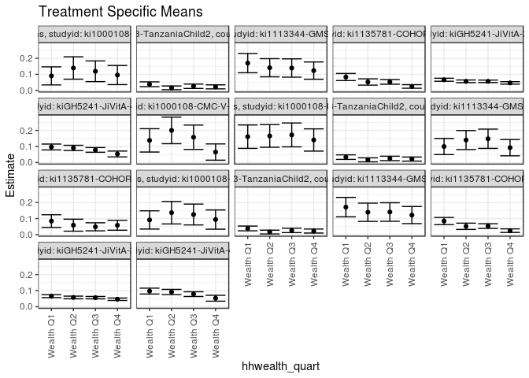

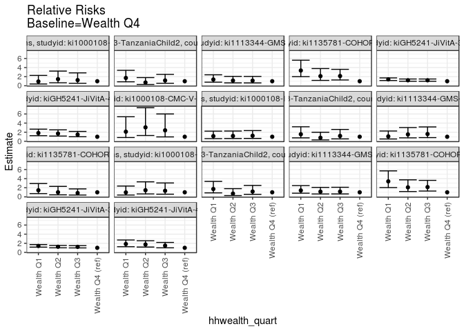

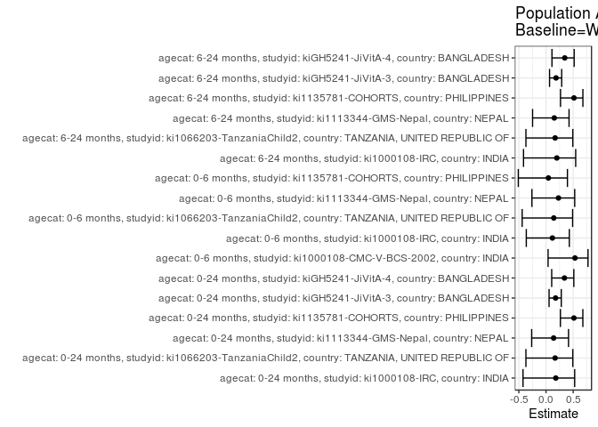

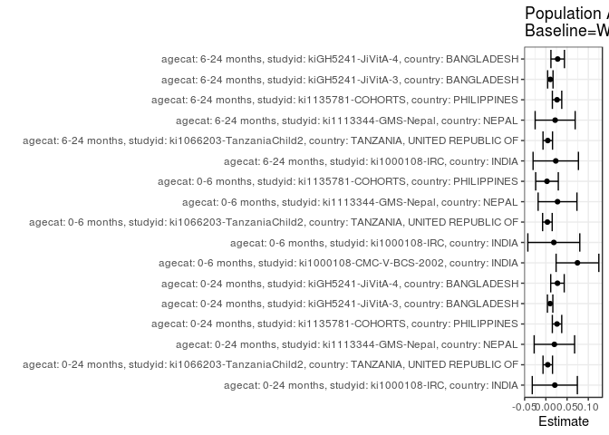

## Results Table

### Parameter: TSM

| agecat | studyid | country | intervention_level | baseline_level | estimate | ci_lower | ci_upper |
| --- | --- | --- | --- | --- | --- | --- | --- |
| 0-24 months | ki1000108-IRC | INDIA | Wealth Q4 | NA | 0.0959875 | 0.0365197 | 0.1554553 |
| 0-24 months | ki1000108-IRC | INDIA | Wealth Q1 | NA | 0.0905861 | 0.0344546 | 0.1467175 |
| 0-24 months | ki1000108-IRC | INDIA | Wealth Q2 | NA | 0.1398622 | 0.0702793 | 0.2094451 |
| 0-24 months | ki1000108-IRC | INDIA | Wealth Q3 | NA | 0.1193661 | 0.0550082 | 0.1837241 |
| 0-24 months | ki1066203-TanzaniaChild2 | TANZANIA, UNITED REPUBLIC OF | Wealth Q4 | NA | 0.0223881 | 0.0098607 | 0.0349154 |
| 0-24 months | ki1066203-TanzaniaChild2 | TANZANIA, UNITED REPUBLIC OF | Wealth Q1 | NA | 0.0385208 | 0.0237112 | 0.0533304 |
| 0-24 months | ki1066203-TanzaniaChild2 | TANZANIA, UNITED REPUBLIC OF | Wealth Q2 | NA | 0.0160183 | 0.0042447 | 0.0277919 |
| 0-24 months | ki1066203-TanzaniaChild2 | TANZANIA, UNITED REPUBLIC OF | Wealth Q3 | NA | 0.0261682 | 0.0126381 | 0.0396983 |
| 0-24 months | ki1113344-GMS-Nepal | NEPAL | Wealth Q4 | NA | 0.1235145 | 0.0698434 | 0.1771856 |
| 0-24 months | ki1113344-GMS-Nepal | NEPAL | Wealth Q1 | NA | 0.1701364 | 0.1101854 | 0.2300873 |
| 0-24 months | ki1113344-GMS-Nepal | NEPAL | Wealth Q2 | NA | 0.1413434 | 0.0849216 | 0.1977651 |
| 0-24 months | ki1113344-GMS-Nepal | NEPAL | Wealth Q3 | NA | 0.1396411 | 0.0826817 | 0.1966006 |
| 0-24 months | ki1135781-COHORTS | PHILIPPINES | Wealth Q4 | NA | 0.0249043 | 0.0138417 | 0.0359669 |
| 0-24 months | ki1135781-COHORTS | PHILIPPINES | Wealth Q1 | NA | 0.0835061 | 0.0615287 | 0.1054834 |
| 0-24 months | ki1135781-COHORTS | PHILIPPINES | Wealth Q2 | NA | 0.0527188 | 0.0331723 | 0.0722652 |
| 0-24 months | ki1135781-COHORTS | PHILIPPINES | Wealth Q3 | NA | 0.0533564 | 0.0388516 | 0.0678612 |
| 0-24 months | kiGH5241-JiVitA-3 | BANGLADESH | Wealth Q4 | NA | 0.0471488 | 0.0395249 | 0.0547728 |
| 0-24 months | kiGH5241-JiVitA-3 | BANGLADESH | Wealth Q1 | NA | 0.0666213 | 0.0573545 | 0.0758882 |
| 0-24 months | kiGH5241-JiVitA-3 | BANGLADESH | Wealth Q2 | NA | 0.0569297 | 0.0486682 | 0.0651912 |
| 0-24 months | kiGH5241-JiVitA-3 | BANGLADESH | Wealth Q3 | NA | 0.0569132 | 0.0493134 | 0.0645130 |
| 0-24 months | kiGH5241-JiVitA-4 | BANGLADESH | Wealth Q4 | NA | 0.0533361 | 0.0351473 | 0.0715248 |
| 0-24 months | kiGH5241-JiVitA-4 | BANGLADESH | Wealth Q1 | NA | 0.0967629 | 0.0785384 | 0.1149874 |
| 0-24 months | kiGH5241-JiVitA-4 | BANGLADESH | Wealth Q2 | NA | 0.0910356 | 0.0746566 | 0.1074146 |
| 0-24 months | kiGH5241-JiVitA-4 | BANGLADESH | Wealth Q3 | NA | 0.0786109 | 0.0639905 | 0.0932313 |
| 0-6 months | ki1000108-CMC-V-BCS-2002 | INDIA | Wealth Q4 | NA | 0.0652174 | 0.0146933 | 0.1157415 |
| 0-6 months | ki1000108-CMC-V-BCS-2002 | INDIA | Wealth Q1 | NA | 0.1379310 | 0.0653709 | 0.2104911 |
| 0-6 months | ki1000108-CMC-V-BCS-2002 | INDIA | Wealth Q2 | NA | 0.2000000 | 0.1172450 | 0.2827550 |
| 0-6 months | ki1000108-CMC-V-BCS-2002 | INDIA | Wealth Q3 | NA | 0.1573034 | 0.0815564 | 0.2330503 |
| 0-6 months | ki1000108-IRC | INDIA | Wealth Q4 | NA | 0.1404496 | 0.0712616 | 0.2096376 |
| 0-6 months | ki1000108-IRC | INDIA | Wealth Q1 | NA | 0.1608932 | 0.0879622 | 0.2338241 |
| 0-6 months | ki1000108-IRC | INDIA | Wealth Q2 | NA | 0.1654469 | 0.0949094 | 0.2359844 |
| 0-6 months | ki1000108-IRC | INDIA | Wealth Q3 | NA | 0.1718414 | 0.0975480 | 0.2461348 |
| 0-6 months | ki1066203-TanzaniaChild2 | TANZANIA, UNITED REPUBLIC OF | Wealth Q4 | NA | 0.0216963 | 0.0090116 | 0.0343809 |
| 0-6 months | ki1066203-TanzaniaChild2 | TANZANIA, UNITED REPUBLIC OF | Wealth Q1 | NA | 0.0337079 | 0.0195326 | 0.0478831 |
| 0-6 months | ki1066203-TanzaniaChild2 | TANZANIA, UNITED REPUBLIC OF | Wealth Q2 | NA | 0.0168675 | 0.0044749 | 0.0292600 |
| 0-6 months | ki1066203-TanzaniaChild2 | TANZANIA, UNITED REPUBLIC OF | Wealth Q3 | NA | 0.0255906 | 0.0118554 | 0.0393257 |
| 0-6 months | ki1113344-GMS-Nepal | NEPAL | Wealth Q4 | NA | 0.0924274 | 0.0419860 | 0.1428688 |
| 0-6 months | ki1113344-GMS-Nepal | NEPAL | Wealth Q1 | NA | 0.0997474 | 0.0495087 | 0.1499860 |
| 0-6 months | ki1113344-GMS-Nepal | NEPAL | Wealth Q2 | NA | 0.1399466 | 0.0807547 | 0.1991384 |
| 0-6 months | ki1113344-GMS-Nepal | NEPAL | Wealth Q3 | NA | 0.1478795 | 0.0879391 | 0.2078200 |
| 0-6 months | ki1135781-COHORTS | PHILIPPINES | Wealth Q4 | NA | 0.0582960 | 0.0275260 | 0.0890659 |
| 0-6 months | ki1135781-COHORTS | PHILIPPINES | Wealth Q1 | NA | 0.0842105 | 0.0447005 | 0.1237205 |
| 0-6 months | ki1135781-COHORTS | PHILIPPINES | Wealth Q2 | NA | 0.0588235 | 0.0215184 | 0.0961286 |
| 0-6 months | ki1135781-COHORTS | PHILIPPINES | Wealth Q3 | NA | 0.0487805 | 0.0238446 | 0.0737164 |
| 6-24 months | ki1000108-IRC | INDIA | Wealth Q4 | NA | 0.0937615 | 0.0340006 | 0.1535223 |
| 6-24 months | ki1000108-IRC | INDIA | Wealth Q1 | NA | 0.0914228 | 0.0346994 | 0.1481463 |
| 6-24 months | ki1000108-IRC | INDIA | Wealth Q2 | NA | 0.1364320 | 0.0665193 | 0.2063447 |
| 6-24 months | ki1000108-IRC | INDIA | Wealth Q3 | NA | 0.1251485 | 0.0602395 | 0.1900575 |
| 6-24 months | ki1066203-TanzaniaChild2 | TANZANIA, UNITED REPUBLIC OF | Wealth Q4 | NA | 0.0223881 | 0.0098607 | 0.0349154 |
| 6-24 months | ki1066203-TanzaniaChild2 | TANZANIA, UNITED REPUBLIC OF | Wealth Q1 | NA | 0.0385208 | 0.0237112 | 0.0533304 |
| 6-24 months | ki1066203-TanzaniaChild2 | TANZANIA, UNITED REPUBLIC OF | Wealth Q2 | NA | 0.0160183 | 0.0042447 | 0.0277919 |
| 6-24 months | ki1066203-TanzaniaChild2 | TANZANIA, UNITED REPUBLIC OF | Wealth Q3 | NA | 0.0261682 | 0.0126381 | 0.0396983 |
| 6-24 months | ki1113344-GMS-Nepal | NEPAL | Wealth Q4 | NA | 0.1216973 | 0.0685987 | 0.1747959 |
| 6-24 months | ki1113344-GMS-Nepal | NEPAL | Wealth Q1 | NA | 0.1712009 | 0.1107526 | 0.2316492 |
| 6-24 months | ki1113344-GMS-Nepal | NEPAL | Wealth Q2 | NA | 0.1391210 | 0.0824878 | 0.1957541 |
| 6-24 months | ki1113344-GMS-Nepal | NEPAL | Wealth Q3 | NA | 0.1407357 | 0.0831556 | 0.1983157 |
| 6-24 months | ki1135781-COHORTS | PHILIPPINES | Wealth Q4 | NA | 0.0248465 | 0.0138063 | 0.0358867 |
| 6-24 months | ki1135781-COHORTS | PHILIPPINES | Wealth Q1 | NA | 0.0845731 | 0.0624022 | 0.1067440 |
| 6-24 months | ki1135781-COHORTS | PHILIPPINES | Wealth Q2 | NA | 0.0519112 | 0.0324540 | 0.0713684 |
| 6-24 months | ki1135781-COHORTS | PHILIPPINES | Wealth Q3 | NA | 0.0534622 | 0.0389724 | 0.0679521 |
| 6-24 months | kiGH5241-JiVitA-3 | BANGLADESH | Wealth Q4 | NA | 0.0466727 | 0.0391330 | 0.0542124 |
| 6-24 months | kiGH5241-JiVitA-3 | BANGLADESH | Wealth Q1 | NA | 0.0657402 | 0.0567377 | 0.0747427 |
| 6-24 months | kiGH5241-JiVitA-3 | BANGLADESH | Wealth Q2 | NA | 0.0577320 | 0.0494745 | 0.0659896 |
| 6-24 months | kiGH5241-JiVitA-3 | BANGLADESH | Wealth Q3 | NA | 0.0564547 | 0.0490446 | 0.0638647 |
| 6-24 months | kiGH5241-JiVitA-4 | BANGLADESH | Wealth Q4 | NA | 0.0528624 | 0.0346497 | 0.0710750 |
| 6-24 months | kiGH5241-JiVitA-4 | BANGLADESH | Wealth Q1 | NA | 0.0973130 | 0.0789943 | 0.1156317 |
| 6-24 months | kiGH5241-JiVitA-4 | BANGLADESH | Wealth Q2 | NA | 0.0915841 | 0.0752800 | 0.1078882 |
| 6-24 months | kiGH5241-JiVitA-4 | BANGLADESH | Wealth Q3 | NA | 0.0783792 | 0.0637495 | 0.0930090 |

### Parameter: E(Y)

| agecat | studyid | country | intervention_level | baseline_level | estimate | ci_lower | ci_upper |
| --- | --- | --- | --- | --- | --- | --- | --- |
| 0-24 months | ki1000108-IRC | INDIA | NA | NA | 0.1170732 | 0.0859146 | 0.1482317 |
| 0-24 months | ki1066203-TanzaniaChild2 | TANZANIA, UNITED REPUBLIC OF | NA | NA | 0.0268892 | 0.0200612 | 0.0337172 |
| 0-24 months | ki1113344-GMS-Nepal | NEPAL | NA | NA | 0.1435811 | 0.1153098 | 0.1718524 |
| 0-24 months | ki1135781-COHORTS | PHILIPPINES | NA | NA | 0.0512273 | 0.0430760 | 0.0593786 |
| 0-24 months | kiGH5241-JiVitA-3 | BANGLADESH | NA | NA | 0.0572358 | 0.0531429 | 0.0613287 |
| 0-24 months | kiGH5241-JiVitA-4 | BANGLADESH | NA | NA | 0.0806971 | 0.0720842 | 0.0893100 |
| 0-6 months | ki1000108-CMC-V-BCS-2002 | INDIA | NA | NA | 0.1396648 | 0.1037072 | 0.1756225 |
| 0-6 months | ki1000108-IRC | INDIA | NA | NA | 0.1592040 | 0.1233945 | 0.1950135 |
| 0-6 months | ki1066203-TanzaniaChild2 | TANZANIA, UNITED REPUBLIC OF | NA | NA | 0.0253288 | 0.0185306 | 0.0321270 |
| 0-6 months | ki1113344-GMS-Nepal | NEPAL | NA | NA | 0.1199262 | 0.0925505 | 0.1473020 |
| 0-6 months | ki1135781-COHORTS | PHILIPPINES | NA | NA | 0.0609613 | 0.0448957 | 0.0770269 |
| 6-24 months | ki1000108-IRC | INDIA | NA | NA | 0.1170732 | 0.0859146 | 0.1482317 |
| 6-24 months | ki1066203-TanzaniaChild2 | TANZANIA, UNITED REPUBLIC OF | NA | NA | 0.0268892 | 0.0200612 | 0.0337172 |
| 6-24 months | ki1113344-GMS-Nepal | NEPAL | NA | NA | 0.1435811 | 0.1153098 | 0.1718524 |
| 6-24 months | ki1135781-COHORTS | PHILIPPINES | NA | NA | 0.0512273 | 0.0430760 | 0.0593786 |
| 6-24 months | kiGH5241-JiVitA-3 | BANGLADESH | NA | NA | 0.0572358 | 0.0531429 | 0.0613287 |
| 6-24 months | kiGH5241-JiVitA-4 | BANGLADESH | NA | NA | 0.0806971 | 0.0720842 | 0.0893100 |

### Parameter: RR

| agecat | studyid | country | intervention_level | baseline_level | estimate | ci_lower | ci_upper |
| --- | --- | --- | --- | --- | --- | --- | --- |
| 0-24 months | ki1000108-IRC | INDIA | Wealth Q4 | Wealth Q4 | 1.0000000 | 1.0000000 | 1.000000 |
| 0-24 months | ki1000108-IRC | INDIA | Wealth Q1 | Wealth Q4 | 0.9437278 | 0.3920769 | 2.271549 |
| 0-24 months | ki1000108-IRC | INDIA | Wealth Q2 | Wealth Q4 | 1.4570875 | 0.6575412 | 3.228853 |
| 0-24 months | ki1000108-IRC | INDIA | Wealth Q3 | Wealth Q4 | 1.2435590 | 0.5465085 | 2.829671 |
| 0-24 months | ki1066203-TanzaniaChild2 | TANZANIA, UNITED REPUBLIC OF | Wealth Q4 | Wealth Q4 | 1.0000000 | 1.0000000 | 1.000000 |
| 0-24 months | ki1066203-TanzaniaChild2 | TANZANIA, UNITED REPUBLIC OF | Wealth Q1 | Wealth Q4 | 1.7205958 | 0.8726409 | 3.392518 |
| 0-24 months | ki1066203-TanzaniaChild2 | TANZANIA, UNITED REPUBLIC OF | Wealth Q2 | Wealth Q4 | 0.7154845 | 0.2840630 | 1.802128 |
| 0-24 months | ki1066203-TanzaniaChild2 | TANZANIA, UNITED REPUBLIC OF | Wealth Q3 | Wealth Q4 | 1.1688474 | 0.5456139 | 2.503976 |
| 0-24 months | ki1113344-GMS-Nepal | NEPAL | Wealth Q4 | Wealth Q4 | 1.0000000 | 1.0000000 | 1.000000 |
| 0-24 months | ki1113344-GMS-Nepal | NEPAL | Wealth Q1 | Wealth Q4 | 1.3774605 | 0.7870673 | 2.410718 |
| 0-24 months | ki1113344-GMS-Nepal | NEPAL | Wealth Q2 | Wealth Q4 | 1.1443461 | 0.6342773 | 2.064599 |
| 0-24 months | ki1113344-GMS-Nepal | NEPAL | Wealth Q3 | Wealth Q4 | 1.1305646 | 0.6229539 | 2.051799 |
| 0-24 months | ki1135781-COHORTS | PHILIPPINES | Wealth Q4 | Wealth Q4 | 1.0000000 | 1.0000000 | 1.000000 |
| 0-24 months | ki1135781-COHORTS | PHILIPPINES | Wealth Q1 | Wealth Q4 | 3.3530795 | 2.0007396 | 5.619493 |
| 0-24 months | ki1135781-COHORTS | PHILIPPINES | Wealth Q2 | Wealth Q4 | 2.1168550 | 1.1867697 | 3.775859 |
| 0-24 months | ki1135781-COHORTS | PHILIPPINES | Wealth Q3 | Wealth Q4 | 2.1424587 | 1.2726674 | 3.606700 |
| 0-24 months | kiGH5241-JiVitA-3 | BANGLADESH | Wealth Q4 | Wealth Q4 | 1.0000000 | 1.0000000 | 1.000000 |
| 0-24 months | kiGH5241-JiVitA-3 | BANGLADESH | Wealth Q1 | Wealth Q4 | 1.4130012 | 1.1567927 | 1.725955 |
| 0-24 months | kiGH5241-JiVitA-3 | BANGLADESH | Wealth Q2 | Wealth Q4 | 1.2074465 | 0.9792527 | 1.488816 |
| 0-24 months | kiGH5241-JiVitA-3 | BANGLADESH | Wealth Q3 | Wealth Q4 | 1.2070971 | 0.9795840 | 1.487451 |
| 0-24 months | kiGH5241-JiVitA-4 | BANGLADESH | Wealth Q4 | Wealth Q4 | 1.0000000 | 1.0000000 | 1.000000 |
| 0-24 months | kiGH5241-JiVitA-4 | BANGLADESH | Wealth Q1 | Wealth Q4 | 1.8142112 | 1.2343628 | 2.666447 |
| 0-24 months | kiGH5241-JiVitA-4 | BANGLADESH | Wealth Q2 | Wealth Q4 | 1.7068307 | 1.1564712 | 2.519104 |
| 0-24 months | kiGH5241-JiVitA-4 | BANGLADESH | Wealth Q3 | Wealth Q4 | 1.4738797 | 1.0014378 | 2.169202 |
| 0-6 months | ki1000108-CMC-V-BCS-2002 | INDIA | Wealth Q4 | Wealth Q4 | 1.0000000 | 1.0000000 | 1.000000 |
| 0-6 months | ki1000108-CMC-V-BCS-2002 | INDIA | Wealth Q1 | Wealth Q4 | 2.1149425 | 0.8291086 | 5.394929 |
| 0-6 months | ki1000108-CMC-V-BCS-2002 | INDIA | Wealth Q2 | Wealth Q4 | 3.0666667 | 1.2741917 | 7.380714 |
| 0-6 months | ki1000108-CMC-V-BCS-2002 | INDIA | Wealth Q3 | Wealth Q4 | 2.4119850 | 0.9687855 | 6.005119 |
| 0-6 months | ki1000108-IRC | INDIA | Wealth Q4 | Wealth Q4 | 1.0000000 | 1.0000000 | 1.000000 |
| 0-6 months | ki1000108-IRC | INDIA | Wealth Q1 | Wealth Q4 | 1.1455582 | 0.5872340 | 2.234720 |
| 0-6 months | ki1000108-IRC | INDIA | Wealth Q2 | Wealth Q4 | 1.1779807 | 0.6141453 | 2.259463 |
| 0-6 months | ki1000108-IRC | INDIA | Wealth Q3 | Wealth Q4 | 1.2235091 | 0.6357586 | 2.354627 |
| 0-6 months | ki1066203-TanzaniaChild2 | TANZANIA, UNITED REPUBLIC OF | Wealth Q4 | Wealth Q4 | 1.0000000 | 1.0000000 | 1.000000 |
| 0-6 months | ki1066203-TanzaniaChild2 | TANZANIA, UNITED REPUBLIC OF | Wealth Q1 | Wealth Q4 | 1.5536261 | 0.7560946 | 3.192397 |
| 0-6 months | ki1066203-TanzaniaChild2 | TANZANIA, UNITED REPUBLIC OF | Wealth Q2 | Wealth Q4 | 0.7774371 | 0.3040121 | 1.988106 |
| 0-6 months | ki1066203-TanzaniaChild2 | TANZANIA, UNITED REPUBLIC OF | Wealth Q3 | Wealth Q4 | 1.1794918 | 0.5333532 | 2.608404 |
| 0-6 months | ki1113344-GMS-Nepal | NEPAL | Wealth Q4 | Wealth Q4 | 1.0000000 | 1.0000000 | 1.000000 |
| 0-6 months | ki1113344-GMS-Nepal | NEPAL | Wealth Q1 | Wealth Q4 | 1.0791968 | 0.5134350 | 2.268380 |
| 0-6 months | ki1113344-GMS-Nepal | NEPAL | Wealth Q2 | Wealth Q4 | 1.5141241 | 0.7589639 | 3.020660 |
| 0-6 months | ki1113344-GMS-Nepal | NEPAL | Wealth Q3 | Wealth Q4 | 1.5999532 | 0.8105416 | 3.158197 |
| 0-6 months | ki1135781-COHORTS | PHILIPPINES | Wealth Q4 | Wealth Q4 | 1.0000000 | 1.0000000 | 1.000000 |
| 0-6 months | ki1135781-COHORTS | PHILIPPINES | Wealth Q1 | Wealth Q4 | 1.4445344 | 0.7128959 | 2.927047 |
| 0-6 months | ki1135781-COHORTS | PHILIPPINES | Wealth Q2 | Wealth Q4 | 1.0090498 | 0.4421567 | 2.302761 |
| 0-6 months | ki1135781-COHORTS | PHILIPPINES | Wealth Q3 | Wealth Q4 | 0.8367730 | 0.4013236 | 1.744699 |
| 6-24 months | ki1000108-IRC | INDIA | Wealth Q4 | Wealth Q4 | 1.0000000 | 1.0000000 | 1.000000 |
| 6-24 months | ki1000108-IRC | INDIA | Wealth Q1 | Wealth Q4 | 0.9750578 | 0.4006227 | 2.373150 |
| 6-24 months | ki1000108-IRC | INDIA | Wealth Q2 | Wealth Q4 | 1.4550969 | 0.6412923 | 3.301625 |
| 6-24 months | ki1000108-IRC | INDIA | Wealth Q3 | Wealth Q4 | 1.3347542 | 0.5844955 | 3.048045 |
| 6-24 months | ki1066203-TanzaniaChild2 | TANZANIA, UNITED REPUBLIC OF | Wealth Q4 | Wealth Q4 | 1.0000000 | 1.0000000 | 1.000000 |
| 6-24 months | ki1066203-TanzaniaChild2 | TANZANIA, UNITED REPUBLIC OF | Wealth Q1 | Wealth Q4 | 1.7205958 | 0.8726409 | 3.392518 |
| 6-24 months | ki1066203-TanzaniaChild2 | TANZANIA, UNITED REPUBLIC OF | Wealth Q2 | Wealth Q4 | 0.7154845 | 0.2840630 | 1.802128 |
| 6-24 months | ki1066203-TanzaniaChild2 | TANZANIA, UNITED REPUBLIC OF | Wealth Q3 | Wealth Q4 | 1.1688474 | 0.5456139 | 2.503976 |
| 6-24 months | ki1113344-GMS-Nepal | NEPAL | Wealth Q4 | Wealth Q4 | 1.0000000 | 1.0000000 | 1.000000 |
| 6-24 months | ki1113344-GMS-Nepal | NEPAL | Wealth Q1 | Wealth Q4 | 1.4067762 | 0.8022905 | 2.466712 |
| 6-24 months | ki1113344-GMS-Nepal | NEPAL | Wealth Q2 | Wealth Q4 | 1.1431718 | 0.6292826 | 2.076717 |
| 6-24 months | ki1113344-GMS-Nepal | NEPAL | Wealth Q3 | Wealth Q4 | 1.1564401 | 0.6356605 | 2.103880 |
| 6-24 months | ki1135781-COHORTS | PHILIPPINES | Wealth Q4 | Wealth Q4 | 1.0000000 | 1.0000000 | 1.000000 |
| 6-24 months | ki1135781-COHORTS | PHILIPPINES | Wealth Q1 | Wealth Q4 | 3.4038281 | 2.0318037 | 5.702345 |
| 6-24 months | ki1135781-COHORTS | PHILIPPINES | Wealth Q2 | Wealth Q4 | 2.0892791 | 1.1683629 | 3.736071 |
| 6-24 months | ki1135781-COHORTS | PHILIPPINES | Wealth Q3 | Wealth Q4 | 2.1517027 | 1.2784571 | 3.621416 |
| 6-24 months | kiGH5241-JiVitA-3 | BANGLADESH | Wealth Q4 | Wealth Q4 | 1.0000000 | 1.0000000 | 1.000000 |
| 6-24 months | kiGH5241-JiVitA-3 | BANGLADESH | Wealth Q1 | Wealth Q4 | 1.4085353 | 1.1557557 | 1.716601 |
| 6-24 months | kiGH5241-JiVitA-3 | BANGLADESH | Wealth Q2 | Wealth Q4 | 1.2369545 | 1.0015811 | 1.527641 |
| 6-24 months | kiGH5241-JiVitA-3 | BANGLADESH | Wealth Q3 | Wealth Q4 | 1.2095856 | 0.9815601 | 1.490583 |
| 6-24 months | kiGH5241-JiVitA-4 | BANGLADESH | Wealth Q4 | Wealth Q4 | 1.0000000 | 1.0000000 | 1.000000 |
| 6-24 months | kiGH5241-JiVitA-4 | BANGLADESH | Wealth Q1 | Wealth Q4 | 1.8408750 | 1.2469564 | 2.717674 |
| 6-24 months | kiGH5241-JiVitA-4 | BANGLADESH | Wealth Q2 | Wealth Q4 | 1.7325008 | 1.1720234 | 2.561006 |
| 6-24 months | kiGH5241-JiVitA-4 | BANGLADESH | Wealth Q3 | Wealth Q4 | 1.4827040 | 1.0043721 | 2.188841 |

### Parameter: PAR

| agecat | studyid | country | intervention_level | baseline_level | estimate | ci_lower | ci_upper |
| --- | --- | --- | --- | --- | --- | --- | --- |
| 0-24 months | ki1000108-IRC | INDIA | Wealth Q4 | NA | 0.0210857 | -0.0320204 | 0.0741918 |
| 0-24 months | ki1066203-TanzaniaChild2 | TANZANIA, UNITED REPUBLIC OF | Wealth Q4 | NA | 0.0045011 | -0.0067043 | 0.0157066 |
| 0-24 months | ki1113344-GMS-Nepal | NEPAL | Wealth Q4 | NA | 0.0200666 | -0.0275601 | 0.0676932 |
| 0-24 months | ki1135781-COHORTS | PHILIPPINES | Wealth Q4 | NA | 0.0263230 | 0.0152601 | 0.0373860 |
| 0-24 months | kiGH5241-JiVitA-3 | BANGLADESH | Wealth Q4 | NA | 0.0100870 | 0.0037351 | 0.0164389 |
| 0-24 months | kiGH5241-JiVitA-4 | BANGLADESH | Wealth Q4 | NA | 0.0273610 | 0.0114882 | 0.0432339 |
| 0-6 months | ki1000108-CMC-V-BCS-2002 | INDIA | Wealth Q4 | NA | 0.0744474 | 0.0241121 | 0.1247827 |
| 0-6 months | ki1000108-IRC | INDIA | Wealth Q4 | NA | 0.0187544 | -0.0424350 | 0.0799438 |
| 0-6 months | ki1066203-TanzaniaChild2 | TANZANIA, UNITED REPUBLIC OF | Wealth Q4 | NA | 0.0036325 | -0.0076655 | 0.0149306 |
| 0-6 months | ki1113344-GMS-Nepal | NEPAL | Wealth Q4 | NA | 0.0274988 | -0.0182208 | 0.0732183 |
| 0-6 months | ki1135781-COHORTS | PHILIPPINES | Wealth Q4 | NA | 0.0026653 | -0.0239777 | 0.0293084 |
| 6-24 months | ki1000108-IRC | INDIA | Wealth Q4 | NA | 0.0233117 | -0.0301125 | 0.0767360 |
| 6-24 months | ki1066203-TanzaniaChild2 | TANZANIA, UNITED REPUBLIC OF | Wealth Q4 | NA | 0.0045011 | -0.0067043 | 0.0157066 |
| 6-24 months | ki1113344-GMS-Nepal | NEPAL | Wealth Q4 | NA | 0.0218837 | -0.0252652 | 0.0690327 |
| 6-24 months | ki1135781-COHORTS | PHILIPPINES | Wealth Q4 | NA | 0.0263808 | 0.0153346 | 0.0374271 |
| 6-24 months | kiGH5241-JiVitA-3 | BANGLADESH | Wealth Q4 | NA | 0.0105631 | 0.0042292 | 0.0168970 |
| 6-24 months | kiGH5241-JiVitA-4 | BANGLADESH | Wealth Q4 | NA | 0.0278347 | 0.0119347 | 0.0437348 |

### Parameter: PAF

| agecat | studyid | country | intervention_level | baseline_level | estimate | ci_lower | ci_upper |
| --- | --- | --- | --- | --- | --- | --- | --- |
| 0-24 months | ki1000108-IRC | INDIA | Wealth Q4 | NA | 0.1801068 | -0.4237119 | 0.5278365 |
| 0-24 months | ki1066203-TanzaniaChild2 | TANZANIA, UNITED REPUBLIC OF | Wealth Q4 | NA | 0.1673958 | -0.3700147 | 0.4939983 |
| 0-24 months | ki1113344-GMS-Nepal | NEPAL | Wealth Q4 | NA | 0.1397577 | -0.2638457 | 0.4144722 |
| 0-24 months | ki1135781-COHORTS | PHILIPPINES | Wealth Q4 | NA | 0.5138474 | 0.2652620 | 0.6783285 |
| 0-24 months | kiGH5241-JiVitA-3 | BANGLADESH | Wealth Q4 | NA | 0.1762360 | 0.0563359 | 0.2809018 |
| 0-24 months | kiGH5241-JiVitA-4 | BANGLADESH | Wealth Q4 | NA | 0.3390585 | 0.1046761 | 0.5120831 |
| 0-6 months | ki1000108-CMC-V-BCS-2002 | INDIA | Wealth Q4 | NA | 0.5330435 | 0.0379996 | 0.7733386 |
| 0-6 months | ki1000108-IRC | INDIA | Wealth Q4 | NA | 0.1178010 | -0.3630485 | 0.4290188 |
| 0-6 months | ki1066203-TanzaniaChild2 | TANZANIA, UNITED REPUBLIC OF | Wealth Q4 | NA | 0.1434153 | -0.4391886 | 0.4901729 |
| 0-6 months | ki1113344-GMS-Nepal | NEPAL | Wealth Q4 | NA | 0.2292977 | -0.2596547 | 0.5284564 |
| 0-6 months | ki1135781-COHORTS | PHILIPPINES | Wealth Q4 | NA | 0.0437220 | -0.5101151 | 0.3944385 |
| 6-24 months | ki1000108-IRC | INDIA | Wealth Q4 | NA | 0.1991209 | -0.4141708 | 0.5464428 |
| 6-24 months | ki1066203-TanzaniaChild2 | TANZANIA, UNITED REPUBLIC OF | Wealth Q4 | NA | 0.1673958 | -0.3700147 | 0.4939983 |
| 6-24 months | ki1113344-GMS-Nepal | NEPAL | Wealth Q4 | NA | 0.1524138 | -0.2473081 | 0.4240378 |
| 6-24 months | ki1135781-COHORTS | PHILIPPINES | Wealth Q4 | NA | 0.5149761 | 0.2668838 | 0.6791120 |
| 6-24 months | kiGH5241-JiVitA-3 | BANGLADESH | Wealth Q4 | NA | 0.1845541 | 0.0651386 | 0.2887160 |
| 6-24 months | kiGH5241-JiVitA-4 | BANGLADESH | Wealth Q4 | NA | 0.3449287 | 0.1095917 | 0.5180655 |